# DATA 607 HW Week 10

### Word Clouds

#### Comments:

I would argue that “miss” is not as negative as it seems. It is very likely that most female characters were referred to as Miss.

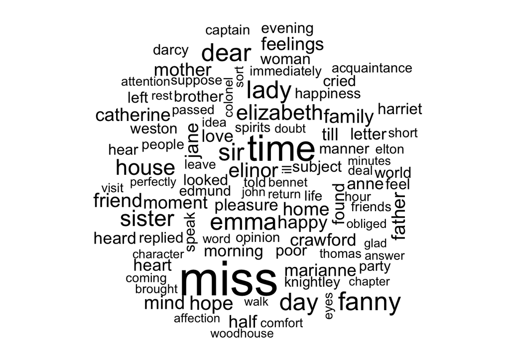

```r
tidy_books %>%
  anti_join(stop_words) %>%
  count(word) %>%
  with(wordcloud(word, n, max.words = 100))
```

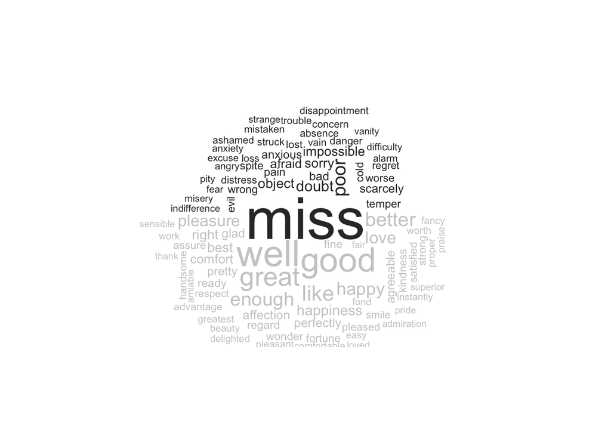

```r
tidy_books %>%
  inner_join(get_sentiments("bing")) %>%
  count(word, sentiment, sort = TRUE) %>%
  acast(word ~ sentiment, value.var = "n", fill = 0) %>%
  comparison.cloud(colors = c("gray20", "gray80"),
                   max.words = 100)
```

### Saddest Chapters

Here, the saddest chapters were selected and displayed in a data frame. The ratio represents the sad words as a ratio to the total words in the chapter.

```r
p_and_p_sentences <- tibble(text = prideprejudice) %>%
  unnest_tokens(sentence, text, token = "sentences")

p_and_p_sentences$sentence[2]
```

```
## [1] "by jane austen"
```

```r
austen_chapters <- austen_books() %>%
  group_by(book) %>%
  unnest_tokens(chapter, text, token = "regex",
                pattern = "Chapter|CHAPTER [\\dIVXLC]") %>%
  ungroup()

austen_chapters %>%
  group_by(book) %>%
  summarise(chapters = n())
```

```
## # A tibble: 6 × 2
##   book                chapters
##   <fct>                  <int>
## 1 Sense & Sensibility       51
## 2 Pride & Prejudice         62
## 3 Mansfield Park            49
## 4 Emma                      56
## 5 Northanger Abbey          32
## 6 Persuasion                25
```

```r
bingnegative <- get_sentiments("bing") %>%
  filter(sentiment == "negative")

wordcounts <- tidy_books %>%
  group_by(book, chapter) %>%
  summarize(words = n())
tidy_books %>%
  semi_join(bingnegative) %>%
  group_by(book, chapter) %>%
  summarize(negativewords = n()) %>%
  left_join(wordcounts, by = c("book", "chapter")) %>%
  mutate(ratio = negativewords/words) %>%
  filter(chapter != 0) %>%
  slice_max(ratio, n = 1) %>%
  ungroup()
```

```
## # A tibble: 6 × 5
##   book                chapter negativewords words  ratio
##   <fct>                 <int>         <int> <int>  <dbl>
## 1 Sense & Sensibility      43           161  3405 0.0473
## 2 Pride & Prejudice        34           111  2104 0.0528
## 3 Mansfield Park           46           173  3685 0.0469
## 4 Emma                     15           151  3340 0.0452
## 5 Northanger Abbey         21           149  2982 0.0500
## 6 Persuasion                4            62  1807 0.0343
```

## Original Work:

I decided to explore Harry Potter for my corpus of choice. I found an R [package](https://github.com/bradleyboehmke/harrypotter) online that contains all of the text for the seven main books in the Harry Potter series. The problem I ran into was that I could not load the correct harrypotter package. I used install.packages(harrypotter). This was a mistake. There is another Harry Potter House package that was being confused with the books package, and I could not resolve the issue for quite some time. I had to remove the package and restart R and clear all consoles and values in order to finally be able to call the correct package. The package installation command is copied from the original package on github.

The other sentiment lexicon I found and will be using was found [here](https://cran.r-project.org/web/packages/tidytext/tidytext.pdf)

Loughran-McDonald Sentiment [lexicon](https://sraf.nd.edu/textual-analysis/resources/)

```r
if (packageVersion("devtools") < 1.6) {
  install.packages("devtools")
}
devtools::install_github("bradleyboehmke/harrypotter", force = TRUE)
library(harrypotter)
```

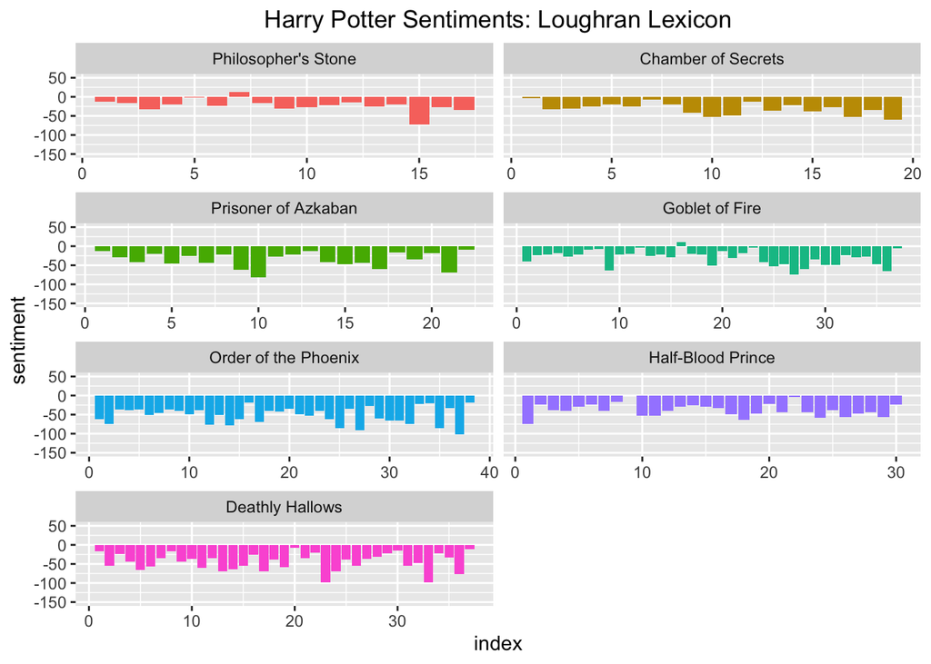

```r
titles <- c("Philosopher's Stone", "Chamber of Secrets", "Prisoner of Azkaban",
            "Goblet of Fire", "Order of the Phoenix", "Half-Blood Prince",
            "Deathly Hallows")
book <- list(philosophers_stone, chamber_of_secrets, prisoner_of_azkaban,
              goblet_of_fire, order_of_the_phoenix, half_blood_prince,
              deathly_hallows)

#df <- data.frame(harrypotter::philosophers_stone)

potter_tidy <-   list(philosophers_stone, chamber_of_secrets, prisoner_of_azkaban,
              goblet_of_fire, order_of_the_phoenix, half_blood_prince,
              deathly_hallows) %>%
  set_names(titles) %>%
  map_df(as_tibble, .id = "book") %>%
  mutate(book = factor(book, levels = titles)) %>%
  drop_na(value) %>%
  group_by(book) %>%
  mutate(chapter = row_number(book)) %>%
  ungroup() %>%
  unnest_tokens(word, value)


potter_sentiment <- potter_tidy %>%
  inner_join(get_sentiments("loughran")) %>%
  count(book, index = chapter, sentiment) %>%
  pivot_wider(names_from = sentiment, values_from = n, values_fill = 0) %>%
  mutate(sentiment = positive - negative)
ggplot(potter_sentiment, aes(index, sentiment, fill = book)) +
  geom_col(show.legend = FALSE) +
  coord_cartesian(ylim = c(-150, 50))+
  facet_wrap(~book, ncol = 2, scales = "free_x")+
  ggtitle("Harry Potter Sentiments: Loughran Lexicon")+
  theme(plot.title = element_text(hjust = 0.5))
```

```r
potter_sentiment <- potter_tidy %>%
  inner_join(get_sentiments("bing")) %>%
  count(book, index = chapter, sentiment) %>%
  pivot_wider(names_from = sentiment, values_from = n, values_fill = 0) %>%
  mutate(sentiment = positive - negative)
```

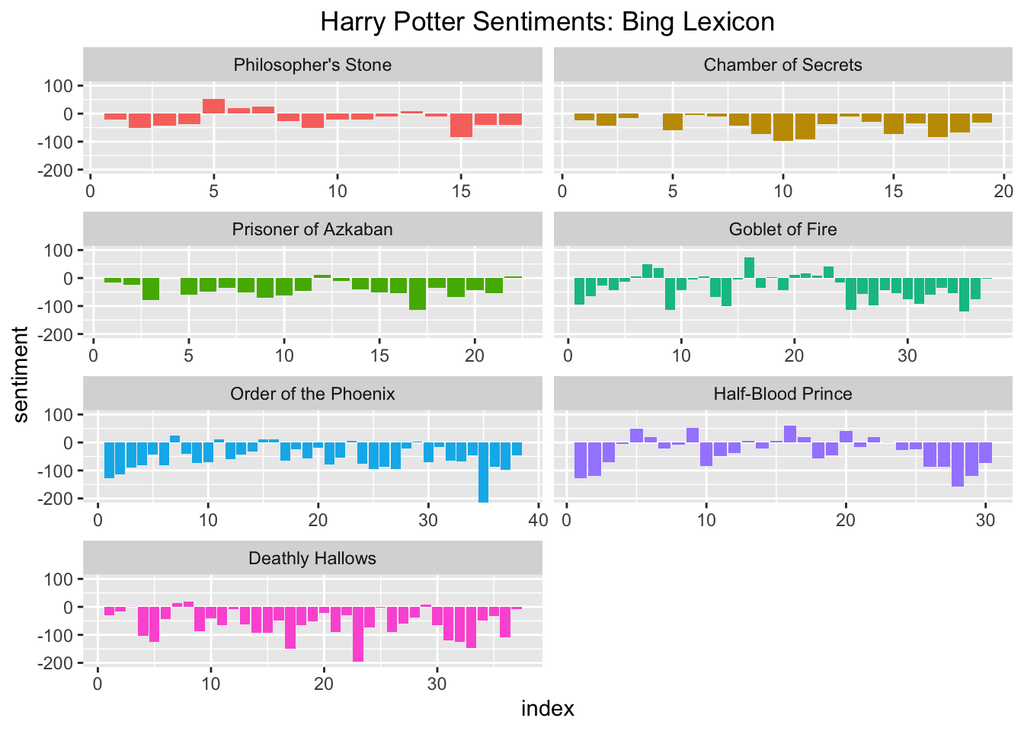

```r
ggplot(potter_sentiment, aes(index, sentiment, fill = book)) +
  geom_col(show.legend = FALSE) +
  coord_cartesian(ylim = c(-200, 100))+
  facet_wrap(~book, ncol = 2, scales = "free_x")+
  ggtitle("Harry Potter Sentiments: Bing Lexicon")+
  theme(plot.title = element_text(hjust = 0.5))
```

```r
potter_sentiment <- potter_tidy %>%
  inner_join(get_sentiments("nrc")) %>%
  count(book, index = chapter, sentiment) %>%
  pivot_wider(names_from = sentiment, values_from = n, values_fill = 0) %>%
  mutate(sentiment = positive - negative)
```

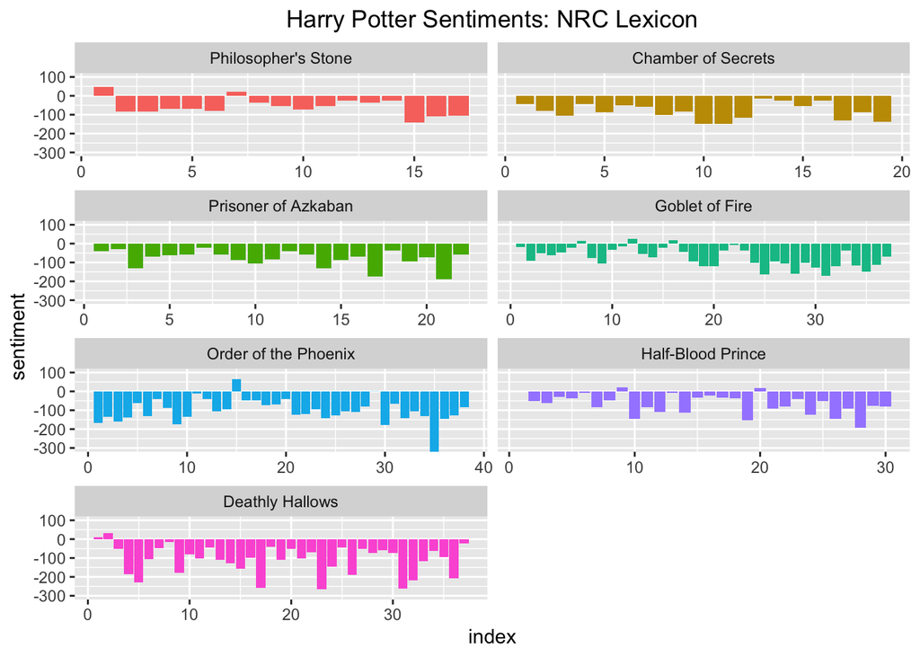

```r
ggplot(potter_sentiment, aes(index, sentiment, fill = book)) +
  geom_col(show.legend = FALSE) +
  coord_cartesian(ylim = c(-300, 100))+
  facet_wrap(~book, ncol = 2, scales = "free_x")+
  ggtitle("Harry Potter Sentiments: NRC Lexicon")+
  theme(plot.title = element_text(hjust = 0.5))
```

### Sentiments

From the three different sentiment lexicons, the Harry Potter books on the whole appear to offer overwhelmingly negative sentiments.

After the third book, the books are divided into more chapters and they seem to get progressively more negative. The widest range seems to be in Order of the Phoenix, so I will analyze that book.

```r
order_phx <- potter_tidy %>%
  filter(book == "Order of the Phoenix")

order_phx
```

```
## # A tibble: 258,763 × 3
##    book                 chapter word
##    <fct>                  <int> <chr>
##  1 Order of the Phoenix       1 dudley
##  2 Order of the Phoenix       1 demented
##  3 Order of the Phoenix       1 the
##  4 Order of the Phoenix       1 hottest
##  5 Order of the Phoenix       1 day
##  6 Order of the Phoenix       1 of
##  7 Order of the Phoenix       1 the
##  8 Order of the Phoenix       1 summer
##  9 Order of the Phoenix       1 so
## 10 Order of the Phoenix       1 far
## # … with 258,753 more rows
```

```r
afinn <- order_phx %>%
  inner_join(get_sentiments("afinn")) %>%
  group_by(index = chapter) %>%
  summarise(sentiment = sum(value)) %>%
  mutate(method = "AFINN")
bing_and_nrc <- bind_rows(
  order_phx %>%
    inner_join(get_sentiments("bing")) %>%
    mutate(method = "Bing et al."),
  order_phx %>%
    inner_join(get_sentiments("nrc") %>%
                 filter(sentiment %in% c("positive",
                                         "negative"))
    ) %>%
    mutate(method = "NRC")) %>%
  count(method, index = chapter, sentiment) %>%
  pivot_wider(names_from = sentiment,
              values_from = n,
              values_fill = 0) %>%
  mutate(sentiment = positive - negative)
loughran <- order_phx %>%
    inner_join(get_sentiments("loughran")) %>%
    mutate(method = "Loughran") %>%
    group_by(index = chapter) %>%
    filter(sentiment %in% c("positive", "negative")) %>%
    mutate(method = "Loughran") %>%
  count(method, index = chapter, sentiment) %>%
  pivot_wider(names_from = sentiment,
              values_from = n,
              values_fill = 0) %>%
  mutate(sentiment = positive - negative)
```

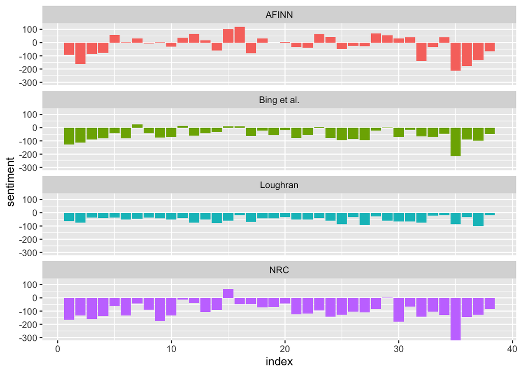

```r
bind_rows(afinn,
          bing_and_nrc, loughran) %>%
  ggplot(aes(index, sentiment, fill = method)) +
  geom_col(show.legend = FALSE) +
  coord_cartesian(ylim = c(-300, 125))+
  facet_wrap(~method, ncol = 1, scales = "free_y")
```

## Further Analysis

NRC seems the most polarized, so I will use NRC to find the ratio of negative words to total words. One peculiar result is that the Loughran Lexicon did not return any positive sentiments.

```r
get_sentiments("nrc") %>%
  filter(sentiment %in% c("positive", "negative")) %>%
  count(sentiment)
```

```
## # A tibble: 2 × 2
##   sentiment     n
##   <chr>     <int>
## 1 negative   3318
## 2 positive   2308
```

```r
get_sentiments("bing") %>%
  count(sentiment)
```

```
## # A tibble: 2 × 2
##   sentiment     n
##   <chr>     <int>
## 1 negative   4781
## 2 positive   2005
```

```r
get_sentiments("loughran") %>%
  filter(sentiment %in% c("positive", "negative")) %>%
  count(sentiment)
```

```
## # A tibble: 2 × 2
##   sentiment     n
##   <chr>     <int>
## 1 negative   2355
## 2 positive    354
```

```r
stone_chapters <- as.numeric(nrow(data.frame(harrypotter::philosophers_stone)))
chamber_chapters <- as.numeric(nrow(data.frame(harrypotter::chamber_of_secrets)))
prisoner_chapters <- as.numeric(nrow(data.frame(harrypotter::prisoner_of_azkaban)))
goblet_chapters <- as.numeric(nrow(data.frame(harrypotter::goblet_of_fire)))
order_chapters <- as.numeric(nrow(data.frame(harrypotter::order_of_the_phoenix)))
prince_chapters <- as.numeric(nrow(data.frame(harrypotter::half_blood_prince)))
deathly_chapters <- as.numeric(nrow(data.frame(harrypotter::deathly_hallows)))

chapters <- data.frame(c(stone_chapters, chamber_chapters, prisoner_chapters, goblet_chapters, order_chapters, prince_chapters, deathly_chapters))
chapters <- cbind(titles,chapters)
colnames(chapters) <- c("title", "count")


nrcnegative <- get_sentiments("nrc") %>%
  filter(sentiment == "negative")

wordcounts <- potter_tidy %>%
  group_by(book, chapter) %>%
  summarize(words = n())
potter_tidy %>%
  semi_join(nrcnegative) %>%
  group_by(book, chapter) %>%
  summarize(negativewords = n()) %>%
  left_join(wordcounts, by = c("book", "chapter")) %>%
  mutate(ratio = negativewords/words) %>%
  filter(chapter != 0) %>%
  slice_max(ratio, n = 1) %>%
  ungroup()
```

```
## # A tibble: 7 × 5
##   book                 chapter negativewords words  ratio
##   <fct>                  <int>         <int> <int>  <dbl>
## 1 Philosopher's Stone       17           318  5488 0.0579
## 2 Chamber of Secrets         2           199  2894 0.0688
## 3 Prisoner of Azkaban        3           284  4415 0.0643
## 4 Goblet of Fire            32           159  2010 0.0791
## 5 Order of the Phoenix      36           268  3845 0.0697
## 6 Half-Blood Prince         28           274  3597 0.0762
## 7 Deathly Hallows           32           375  5552 0.0675
```

## Conclusions and Alternative Plots

The most variation is found in the Order of the Phoenix and Deathly Hallows books. The Bing lexicon seems to be the most effective at getting a wider range of outcomes, which is more in line with expectation in a book. Having all of the lexicons available makes for a more accurate idea of the reality of the data. It appears that the Harry Potter books are largely negative, but I would like to explore which emotion is the main cause of the negativity. My guess is that anger would contribute more to the overall sentiment than sadness would.

Sadness contributed on average just slightly more than anger.

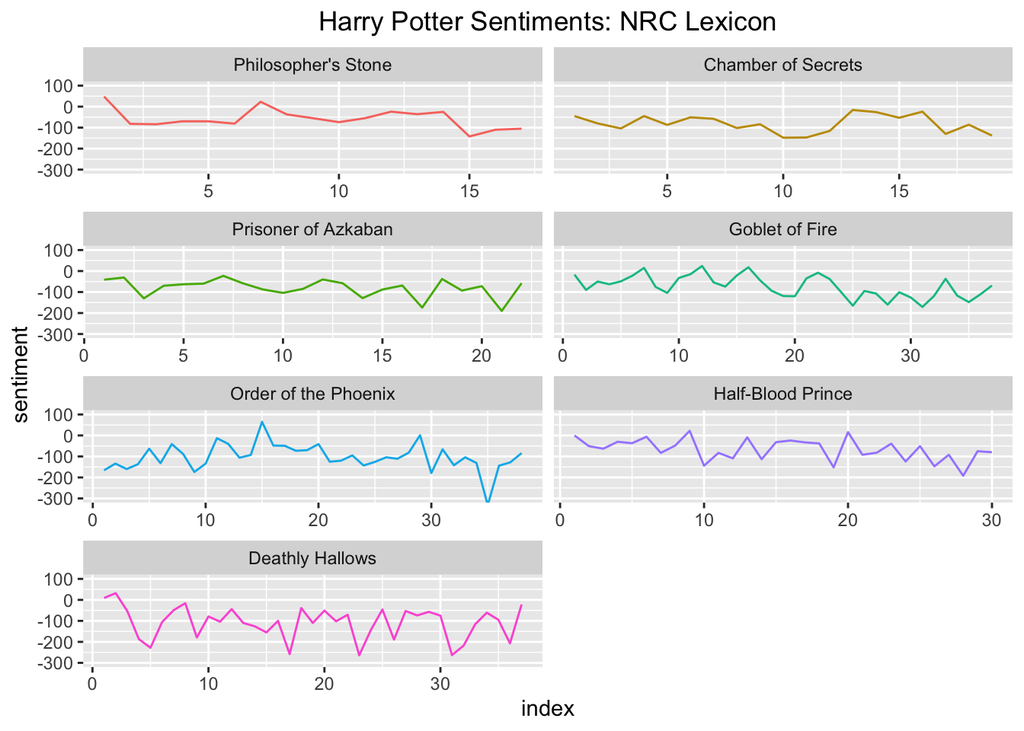

```r
ggplot(potter_sentiment, aes(index, sentiment, fill = book, color = book)) +
  geom_line(show.legend = FALSE) +
  coord_cartesian(ylim = c(-300, 100))+
  facet_wrap(~book, ncol = 2, scales = "free_x")+
  ggtitle("Harry Potter Sentiments: NRC Lexicon")+
  theme(plot.title = element_text(hjust = 0.5))
```

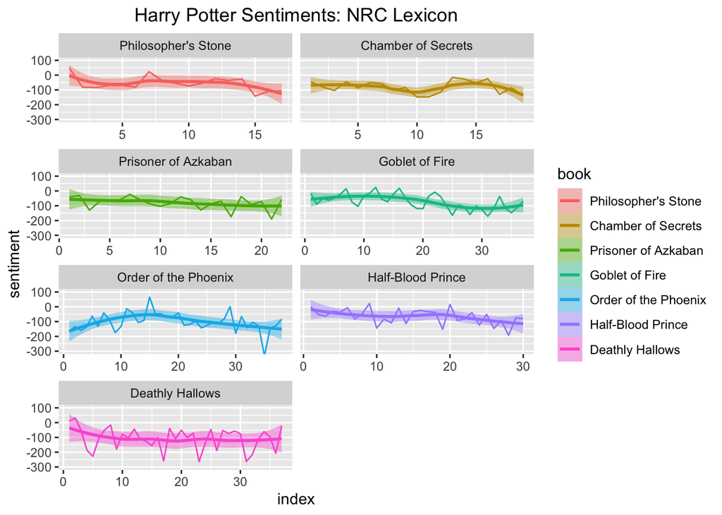

```r
ggplot(potter_sentiment, aes(index, sentiment, fill = book, color = book)) +
  geom_line(show.legend = FALSE) +
  coord_cartesian(ylim = c(-300, 100))+
  facet_wrap(~book, ncol = 2, scales = "free_x")+
  ggtitle("Harry Potter Sentiments: NRC Lexicon")+
  theme(plot.title = element_text(hjust = 0.5))+
  geom_smooth()
```

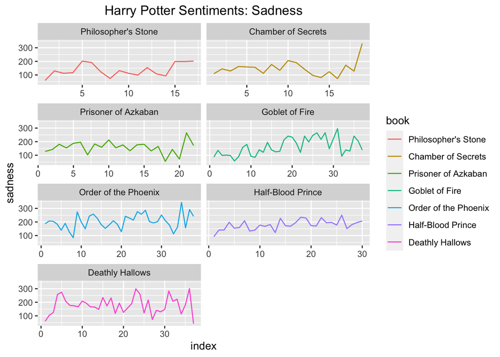

```r
ggplot(potter_sentiment, aes(index, sadness, color = book)) +
  geom_line()+
  facet_wrap(~book, ncol = 2, scales = "free_x")+
  ggtitle("Harry Potter Sentiments: Sadness")+
  theme(plot.title = element_text(hjust = 0.5))
```

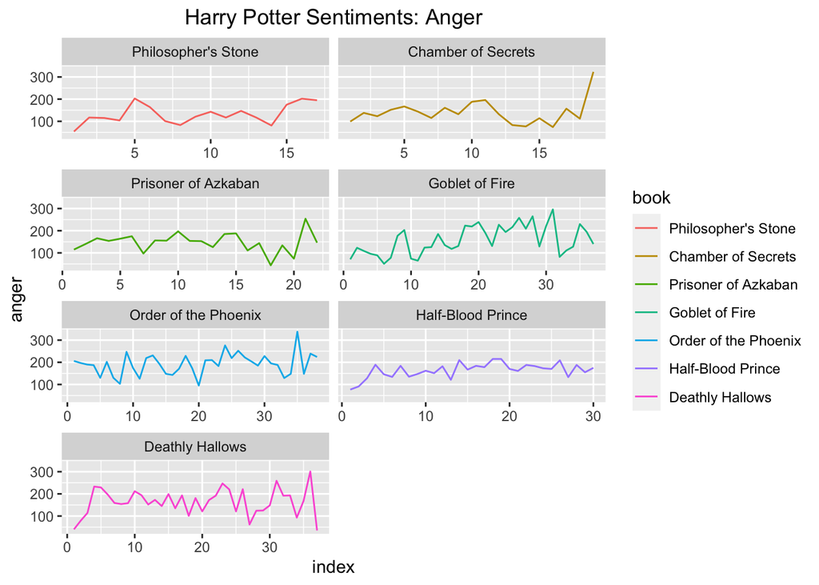

```r
ggplot(potter_sentiment, aes(index, anger, color = book)) +
  geom_line()+
  facet_wrap(~book, ncol = 2, scales = "free_x")+
  ggtitle("Harry Potter Sentiments: Anger")+
  theme(plot.title = element_text(hjust = 0.5))
```

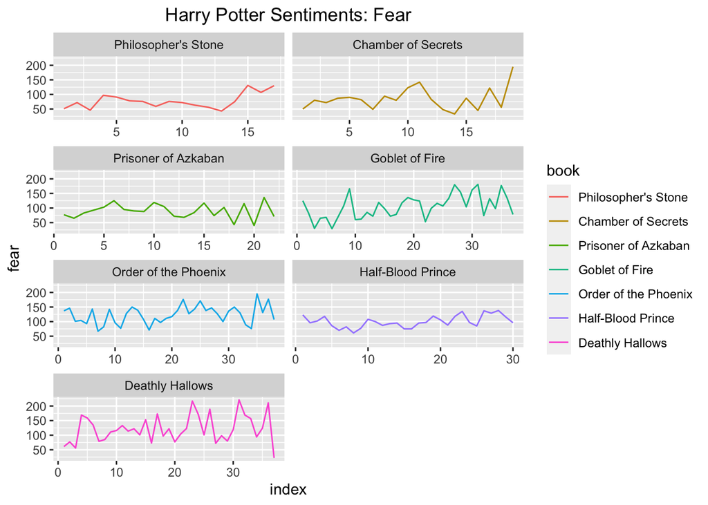

```r
ggplot(potter_sentiment, aes(index, fear, color = book)) +
  geom_line()+
  facet_wrap(~book, ncol = 2, scales = "free_x")+
  ggtitle("Harry Potter Sentiments: Fear")+
  theme(plot.title = element_text(hjust = 0.5))
```

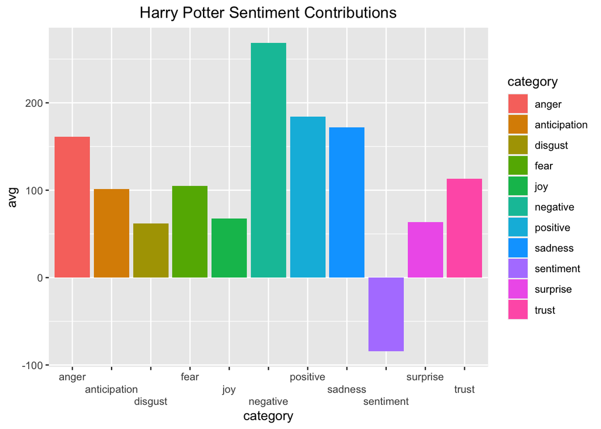

```r
sentiments_avg <- colMeans(potter_sentiment[3:13])
category <- colnames(potter_sentiment[3:13])
avg <- data.frame()
avg <- data.frame(cbind(category,as.numeric(sentiments_avg)))
colnames(avg) <- c("category", "avg")
rownames(avg) <- c(1:11)
avg$category <- as.factor(avg$category)
avg$avg <- as.numeric(avg$avg)


ggplot(avg, aes(x = category, y = avg, fill = category)) +
  geom_col(stat = "identity")+
  ggtitle("Harry Potter Sentiment Contributions")+
  theme(plot.title = element_text(hjust = 0.5))+
  scale_x_discrete(guide = guide_axis(n.dodge = 3))
```